# M2.955_20192_PEC1-Solucion(1)

[figure not shown]

M2.955 · Modelos avanzados de minería de datos · PEC1

2019-2 · Máster universitario en Ciencia de datos (Data science)

Estudios de Informática, Multimedia y Telecomunicación

# PEC 1: Preparación de datos

A lo largo de esta práctica veremos como aplicar diferentes tecnicas para la carga y preparación de datos:

1. Carga de un conjunto de datos
2. Análisis de los datos  
   2.1 Análisis estadístico básico  
   2.2 Análisis expxloratorio de los datos
3. Reducción de la dimensionalidad
4. Entrenamiento y test

Para eso necesitaremos las siguientes librerías:

```python
import numpy as np
import pandas as pd
import seaborn as sns
from sklearn import datasets
from sklearn import preprocessing
from sklearn.manifold import TSNE
from sklearn.decomposition import PCA
from sklearn.ensemble import RandomForestClassifier
from sklearn.metrics import accuracy_score, confusion_matrix
from sklearn.model_selection import train_test_split, cross_val_score

import matplotlib.pyplot as plt


pd.set_option('display.max_columns', None)

%matplotlib inline
```

# 1. Carga del conjunto de datos (1 punto)

En primer lugar, debéis cargar el conjunto de datos Wine recognition (más información en el enlace https://archive.ics.uci.edu/ml/datasets/Wine). Se puede descargar de internet o se puede cargar directamente desde la librería "scikit-learn", que incorpora un conjunto de datasets muy conocidos y usados para la minería de datos y machine learning http://scikit-learn.org/stable/datasets/index.html.

**Ejercicio:** Cargad el conjunto de datos "Wine Recognition" y mostrad:  
- el número y nombre de los atributos (variables que podrían ser usadas para predecir la respuesta "wine_class")  
- el número de filas del conjunto de datos  
- verificad si hay o no "missing values" y en que columnas

Sugerencia: Si usáis sklearn (sklearn.datasets.load_wine), explorad las diferents 'keys' del objecto obtenido. Sugerencia: Igual os resulta útil pasar los datos (atributos + target) a un dataframe de pandas.

**Solución:**

```python
wine = datasets.load_wine()
print("elementos en el diccionario de datos:", wine.keys())
```

```
elementos en el diccionario de datos: dict_keys(['data', 'target', 'target_names', 'DESCR', 'feature_names'])
```

```python
print(wine["DESCR"])
```

```
.. _wine_dataset:

Wine recognition dataset
------------------------

**Data Set Characteristics:**

    :Number of Instances: 178 (50 in each of three classes)
    :Number of Attributes: 13 numeric, predictive attributes and the class
    :Attribute Information:
 		- Alcohol
 		- Malic acid
 		- Ash
		- Alcalinity of ash
 		- Magnesium
		- Total phenols
 		- Flavanoids
 		- Nonflavanoid phenols
 		- Proanthocyanins
		- Color intensity
 		- Hue
 		- OD280/OD315 of diluted wines
 		- Proline

    - class:
            - class_0
            - class_1
            - class_2

    :Summary Statistics:

    ============================= ==== ===== ======= =====
                                   Min   Max   Mean     SD
    ============================= ==== ===== ======= =====
    Alcohol:                      11.0  14.8    13.0   0.8
    Malic Acid:                   0.74  5.80    2.34  1.12
    Ash:                          1.36  3.23    2.36  0.27
    Alcalinity of Ash:            10.6  30.0    19.5   3.3
    Magnesium:                    70.0 162.0    99.7  14.3
    Total Phenols:                0.98  3.88    2.29  0.63
```

[output cut: 40 more lines]

```
  Tech. Rep. no. 92-02, (1992), Dept. of Computer Science and Dept. of
  Mathematics and Statistics, James Cook University of North Queensland.
  (Also submitted to Technometrics).

  The data was used with many others for comparing various
  classifiers. The classes are separable, though only RDA
  has achieved 100% correct classification.
  (RDA : 100%, QDA 99.4%, LDA 98.9%, 1NN 96.1% (z-transformed data))
  (All results using the leave-one-out technique)

  (2) S. Aeberhard, D. Coomans and O. de Vel,
  "THE CLASSIFICATION PERFORMANCE OF RDA"
  Tech. Rep. no. 92-01, (1992), Dept. of Computer Science and Dept. of
  Mathematics and Statistics, James Cook University of North Queensland.
  (Also submitted to Journal of Chemometrics).
```

```python
X = wine["data"]
y = wine["target"]

print("# rows X:", np.shape(X)[0])
print("# rows y:", np.shape(y)[0])
print("# feature columns:", np.shape(X)[1])
print("Feature columns:", wine["feature_names"])
```

```
# rows X: 178
# rows y: 178
# feature columns: 13
Feature columns: ['alcohol', 'malic_acid', 'ash', 'alcalinity_of_ash', 'magnesium', 'total_phenols', 'flavanoids', 'nonflavanoid_phenols', 'proanthocyanins', 'color_intensity', 'hue', 'od280/od315_of_diluted_wines', 'proline']
```

```python
df_wine = pd.concat([pd.DataFrame(data=X, columns=wine["feature_names"]),
                     pd.DataFrame(data=y, columns=["wine_class"])], axis='columns')
print("# rows:", df_wine.shape[0], "# columns:", df_wine.shape[1])
df_wine.head(2)
```

```
# rows: 178 # columns: 14
```

|  | alcohol | malic_acid | ash | alcalinity_of_ash | magnesium | total_phenols | flavanoids | nonflavanoid_phenols | proanthocyanins | color_intensity | hue | od280/od315_of_diluted_wines | proline | wine_class |
| --- | --- | --- | --- | --- | --- | --- | --- | --- | --- | --- | --- | --- | --- | --- |
| 0 | 14.23 | 1.71 | 2.43 | 15.6 | 127.0 | 2.80 | 3.06 | 0.28 | 2.29 | 5.64 | 1.04 | 3.92 | 1065.0 | 0 |
| 1 | 13.20 | 1.78 | 2.14 | 11.2 | 100.0 | 2.65 | 2.76 | 0.26 | 1.28 | 4.38 | 1.05 | 3.40 | 1050.0 | 0 |

```python
df_wine.isna().any()
```

```
alcohol                         False
malic_acid                      False
ash                             False
alcalinity_of_ash               False
magnesium                       False
total_phenols                   False
flavanoids                      False
nonflavanoid_phenols            False
proanthocyanins                 False
color_intensity                 False
hue                             False
od280/od315_of_diluted_wines    False
proline                         False
wine_class                      False
dtype: bool
```

# 2. Análisis de los datos (3 puntos)

## 2.1 Análisis estadístico básico

**Ejercicio:** Realizad un análisis estadístico básico:  
- Variables categóricas: - Calculad la frecuencia. - Haced un gráfico de barras.  
- Variables numéricas: - Calculad estadísticos descriptivos básicos: media, mediana, desviación estandard, ... - Haced un histograma de las variables: alcohol, magnesium y color_intensity

Sugerencia: podéis usar la librería 'pandas' y sus funciones 'describe' y 'value_counts'

**Solución:**

```python
freq = df_wine['wine_class'].value_counts()
freq
```

```
1    71
0    59
2    48
Name: wine_class, dtype: int64
```

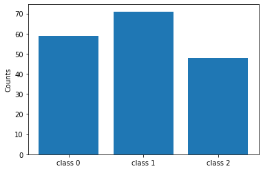

```python
plt.bar(freq.index.values, freq)
plt.xticks(freq.index.values, ('class 1', 'class 0', 'class 2'))
plt.ylabel('Counts')
```

```python
df_wine.drop(columns='wine_class').describe()
```

|  | alcohol | malic_acid | ash | alcalinity_of_ash | magnesium | total_phenols | flavanoids | nonflavanoid_phenols | proanthocyanins | color_intensity | hue | od280/od315_of_diluted_wines | proline |
| --- | --- | --- | --- | --- | --- | --- | --- | --- | --- | --- | --- | --- | --- |
| count | 178.000000 | 178.000000 | 178.000000 | 178.000000 | 178.000000 | 178.000000 | 178.000000 | 178.000000 | 178.000000 | 178.000000 | 178.000000 | 178.000000 | 178.000000 |
| mean | 13.000618 | 2.336348 | 2.366517 | 19.494944 | 99.741573 | 2.295112 | 2.029270 | 0.361854 | 1.590899 | 5.058090 | 0.957449 | 2.611685 | 746.893258 |
| std | 0.811827 | 1.117146 | 0.274344 | 3.339564 | 14.282484 | 0.625851 | 0.998859 | 0.124453 | 0.572359 | 2.318286 | 0.228572 | 0.709990 | 314.907474 |
| min | 11.030000 | 0.740000 | 1.360000 | 10.600000 | 70.000000 | 0.980000 | 0.340000 | 0.130000 | 0.410000 | 1.280000 | 0.480000 | 1.270000 | 278.000000 |
| 25% | 12.362500 | 1.602500 | 2.210000 | 17.200000 | 88.000000 | 1.742500 | 1.205000 | 0.270000 | 1.250000 | 3.220000 | 0.782500 | 1.937500 | 500.500000 |
| 50% | 13.050000 | 1.865000 | 2.360000 | 19.500000 | 98.000000 | 2.355000 | 2.135000 | 0.340000 | 1.555000 | 4.690000 | 0.965000 | 2.780000 | 673.500000 |
| 75% | 13.677500 | 3.082500 | 2.557500 | 21.500000 | 107.000000 | 2.800000 | 2.875000 | 0.437500 | 1.950000 | 6.200000 | 1.120000 | 3.170000 | 985.000000 |
| max | 14.830000 | 5.800000 | 3.230000 | 30.000000 | 162.000000 | 3.880000 | 5.080000 | 0.660000 | 3.580000 | 13.000000 | 1.710000 | 4.000000 | 1680.000000 |

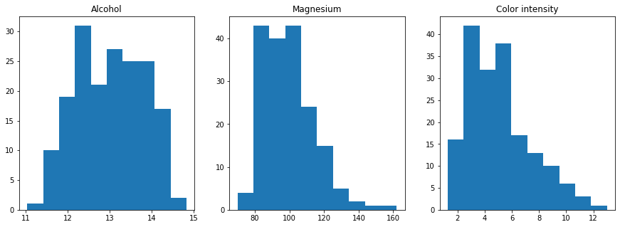

```python
fig, ax = plt.subplots(1, 3, figsize = (15, 5))

ax[0].hist(df_wine['alcohol'])
ax[1].hist(df_wine['magnesium'])
ax[2].hist(df_wine['color_intensity'])

ax[0].set_title('Alcohol')
ax[1].set_title('Magnesium')
ax[2].set_title('Color intensity')
```

**Análisis:** Comentad los resultados.

## 2.2 Análisis exploratorio de los datos

En este ejercicio exploraremos la relación de algunos de los atributos numéricos con la variable respuesta ("wine_class"), tanto gráficamente como cualitativamente, y analizaremos las diferentes correlaciones. Para empezar, seleccionaremos solo 3 atributos para explorar: alcohol, magnesium y color_intensity.

```python
feats_to_explore = ['alcohol', 'magnesium', 'color_intensity']
```

**Ejercicio:** Usando una librería gráfica, como por ejemplo "matplotlib", realizad un gráfico del histograma de valores para cada uno de los atributos seleccionados, separados por los valores de la clase respuesta. Los tres gráficos tienen que estar sobrepuestos, es decir, por ejemplo, en el histograma de la feature "alcohol" tienen que haber en un solo gráfico tres histogramas, uno por cada clase de vino. Añadid una leyenda para saber a que clase corresponde cada histograma. La finalidad es observar como se distribuye cada uno de los atributos en función de la clase que tengan, para poder identificar de manera visual y rápida si algunos atributos permiten diferenciar de forma clara las diferentes clases de vinos.

Sugerencia: podéis usar el parámetro "alpha" en los gráficos para que se aprecien los tres histogramas.

**Solución:**

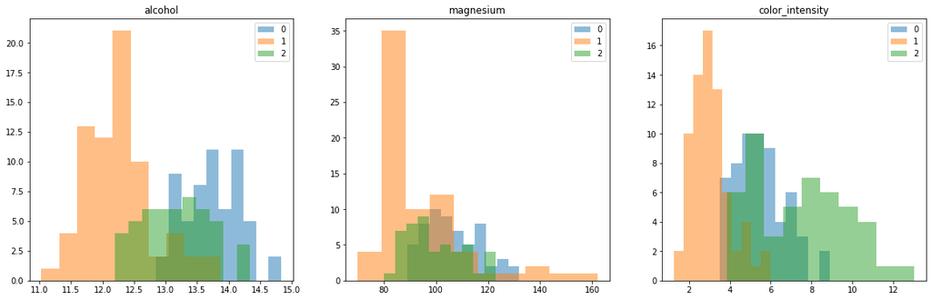

```python
fig, ax = plt.subplots(1, 3, figsize=(20,6))

for i, featName in enumerate(feats_to_explore):
    for wine in df_wine["wine_class"].unique():
        ax[i].hist(df_wine.loc[df_wine["wine_class"]==wine, featName], alpha=0.5, label=wine)
        ax[i].set_title(featName)
        ax[i].legend(loc='upper right')
```

**Análisis:**  
Mirando los histogramas, ¿que atributo parece tener más peso a la hora de clasificar un vino? ¿Cual parece tener menos peso?

**Solución:**  
Entre los atributos seleccionados, el de "alcohol" parece que es el que más diferencia entre las tres clases de vinos. La clase 1 está compuesta por vinos con un grado menor de alcohol, mientras que la clase 0 contiene los vinos con mayor grado de alcohol. La variable "magnesium" es la que parece que tiene menos relación con la clase de vino, ya que las tres distribuciones no quedan muy separadas.

**Ejercicio:** Usando los histogramas anteriores, añadid una linia vertical indicando la media de cada uno de los histogramas (tres por gráfico). Pintad las linias del mismo color que el histograma para que quede claro a cual hacen referencia. Añadid a la leyenda, la clase de vino y la desviación estandard en cuestión. La finalidad es verificar numéricamente las diferencias identificadas anteriormente de forma visual.

Sugerencia: podeis usar "axvline", de matplotlib axis, para las linias verticales.

**Solución:**

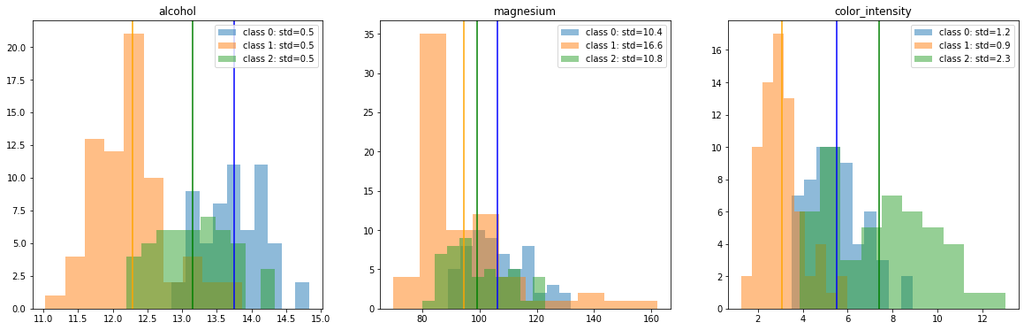

```python
fig, ax = plt.subplots(1, 3, figsize=(20,6))
colors = ['blue', 'orange', 'green']

for i, featName in enumerate(feats_to_explore):
    for wine in df_wine["wine_class"].unique():
        values = df_wine.loc[df_wine["wine_class"]==wine, featName]
        mean = np.mean(values)
        sd = np.round(np.std(values), 1)
        ax[i].hist(values, alpha=0.5, label='class '+str(wine)+': std='+str(sd))
        ax[i].axvline(mean, c = colors[wine])
        ax[i].set_title(featName)
        ax[i].legend(loc='upper right')
```

**Ejercicio:** Calculad y mostrad la correlación entre las tres variables que estamos analizando.

**Solución:**

```python
corr_all = df_wine[feats_to_explore].corr()
corr_all.style.background_gradient(cmap='coolwarm').set_precision(2)
```

|  | alcohol | magnesium | color_intensity |
| --- | --- | --- | --- |
| alcohol | 1.00 | 0.27 | 0.55 |
| magnesium | 0.27 | 1.00 | 0.20 |
| color_intensity | 0.55 | 0.20 | 1.00 |

**Ejercicio:** Representad gráficamente las relaciones entre estas variables (scatterplots). Diferenciad con colores diferentes las diferentes clases. La finalidad es poder observar y analizar las correlaciones de manera gráfica entre algunas de las variables.

Sugerencia: podéis usar la función "pairplot" de la librería 'seaborn' con el parámetro "hue".

**Solución:**

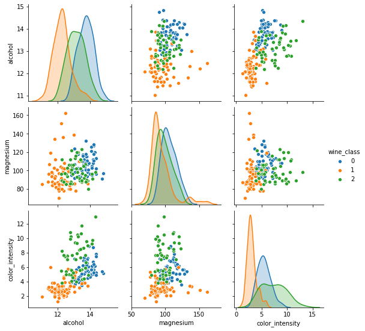

```python
sns.pairplot(df_wine[['alcohol', 'magnesium', 'color_intensity','wine_class']], hue="wine_class")
```

**Análisis:**  
Observando las correlaciones, que variables son las que tienen una correlación más fuerte? Cuadra el resultado numérico con el gráfico obtenido?

**Solución:**  
Las variables que están mas relacionadas son "alcohol" con "color intensity", aunque la correlación es bastante baja (0.55). Gráficamente se aprecia la ligera correlación entre ambas.

# 3. Reducción de la dimensionalidad (2 puntos)

En este ejercicio se aplicarán métodos de reducción de la dimensionalidad al conjunto original de datos. El objetivo es reducir el conjunto de atributos a un nuevo conjunto con menos dimensiones. Así en vez de trabajar con 3 variables elegidas al azahar, usaremos la información de todos los atributos.

**Ejercicio:** Aplicad el método de reducción de la dimensionalidad Principal Component Analysis (PCA) para reducir a 2 dimensiones (el dataset entero con todas las features). Generad un gráfico (en 2D) con el resultado del PCA usando colores diferentes para cada una de las clases de la respuesta (wine_class), con el objetivo de visualizar si es posible separar eficientemente las clases con este método. NOTA: Vigilad de no incluir la variable objetivo "wine class" a la reducción de dimensionalidad. Queremos poder explicar la variable objetivo en funcion del resto de variables reducidas a dos dimensiones.

Sugerencia: No es necesario que programéis el algoritmo, podéis usar la implementación disponible en la librería de "scikit-learn".

**Solución:**

```python
X = df_wine.drop(columns=['wine_class'])
for col in X.columns:
    X[col] = preprocessing.MinMaxScaler().fit_transform(X[col].values.reshape(-1, 1))
X = X.values

y = df_wine["wine_class"]
y = y.values
```

```python
pca = PCA(n_components=2)
X_r_PCA = pca.fit(X).transform(X)
print("Shape of the PCA-reduced dataset:", np.shape(X_r_PCA))
print('Explained variance ratio (first two components): %s' % str(pca.explained_variance_ratio_))
```

```
Shape of the PCA-reduced dataset: (178, 2)
Explained variance ratio (first two components): [0.40749485 0.18970352]
```

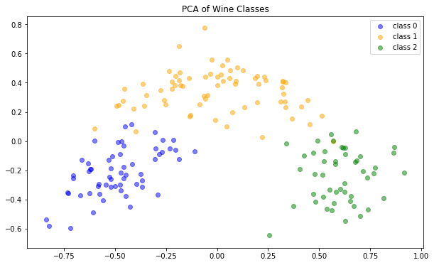

```python
colors = ['blue', 'orange', 'green']
fig, axs = plt.subplots(nrows=1, ncols=1, figsize=(10,6))

for i in range(3):
    axs.scatter(X_r_PCA[y == i, 0], X_r_PCA[y == i, 1], color=colors[i], alpha=.5, label='class '+str(i))
axs.legend()
axs.set_title('PCA of Wine Classes')
```

**Ejercicio:** Repetid la reducción de dimensionalidad, pero en este caso usando TSNE. Podeis encontrar más información sobre este algoritmo al link: [https://distill.pub/2016/misread-tsne/](https://distill.pub/2016/misread-tsne/) Igual que antes, generad un gráfico (en 2D) con el resultado del PCA usando colores diferentes para cada una de las clases de la respuesta (wine_class), con el objetivo de visualizar si es posible separar eficientemente las clases con este método.

Sugerencia: No es necesario que programéis el algoritmo, podéis usar la implementación disponible en la librería de "scikit-learn". Sugerencia: A parte de especificar el número de componentes, probad de usar el parámetro "perplexity".

**Solución:**

```python
tsne = TSNE(n_components=2, perplexity=20)
X_r_TSNE = tsne.fit_transform(X)
print("Shape of the t-SNE-reduced dataset:", np.shape(X_r_TSNE))
```

```
Shape of the t-SNE-reduced dataset: (178, 2)
```

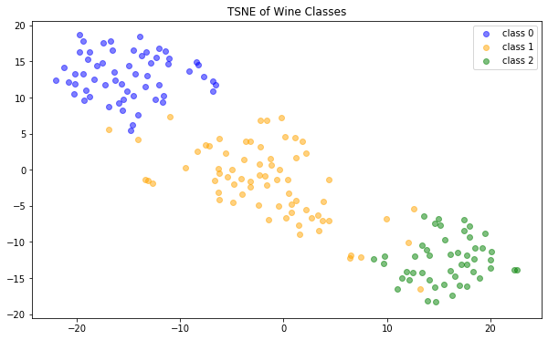

```python
colors = ['blue', 'orange', 'green']
fig, axs = plt.subplots(nrows=1, ncols=1, figsize=(10,6))

for i in range(3):
    axs.scatter(X_r_TSNE[y == i, 0], X_r_TSNE[y == i, 1], color=colors[i], alpha=.5, label='class '+str(i))
axs.legend()
axs.set_title('TSNE of Wine Classes')
```

**Análisis:**  
Observando los dos gráficos, ¿crees que ha funcionado bien la reducción de dimensionalidad? ¿Ha conseguido separar las clases correctamente? ¿Cual de los dos métodos ha funcionado mejor? ¿Por que obtenemos resultados tan diferentes?

**Solución:**  
Los dos métodos son muy diferentes, ya que uno reduce la dimensionalidad basandose en minimizar las distancias (PCA), mientras que el otro se basa en mantener la relación de distancias en alta y baja dimensionalidad (TSNE). En ambos casos las tres clases quedan bastante separades, así a priori no podemos concluir que uno haya funcionado menjor que el otro.